# Final Project Practical ML

This is the final project of the course **Practical Machine Learning** from *coursera*. The goal is to create a classification model based on the *Human Activity Recognition* dataset. (http://groupware.les.inf.puc-rio.br/har)

### Importing data:

First look of our data makes it clear that we have three different inputs which can be evaluated as *NA* values:

```r
library(readr)
#Importing the data, specifing the type of NA values:
pml_train <- read.csv("./pml-training.csv", na.strings=c("NA","#DIV/0!", ""))
pml_test <- read.csv("./pml-testing.csv", na.strings=c("NA","#DIV/0!", ""))
```

### Data cleaning:

Cleaning steps would be: 1. Removing non-informative columns (e.g *name* and *timestamps*, …) 2. Removing columns with *NA* values 3. Changing the type of *classe* from *char* to *factor*

```r
#Removing the non-informative columns (name, timestams, ...)
pml_train <- pml_train[ ,-c(1 :7)]

#Removing columns with NA values
pml_train <- pml_train [colSums(is.na(pml_train)) == 0]

#Changing the datatype of the "classe" column to be factor
pml_train$classe <- factor(pml_train$classe)
```

### Spliting data and creating a simple classificaiton model

To splite the data and create a crosvalidation subset *createDataPartition* from *catet* package is used. To have an understanding of the important features I have created a small classification model using random forest with a limited number of trees.

```r
#Spliting the training data to training and crosValidation
set.seed(123)
inTrain <- createDataPartition(y = pml_train$classe , p=0.7 , list = FALSE)
training <- pml_train[inTrain,]
crosValidation <- pml_train[-inTrain,]
dim(training); dim(crosValidation);
```

```
## [1] 13737    53
```

```
## [1] 5885   53
```

```r
#Training a limited RandomForest Model on the training data:
fitModelRF <- randomForest(classe~., data=pml_train, importance=TRUE, ntree=150)

#Checking the acuracy of the model:
confusionMatrix(crosValidation$classe , predict(fitModelRF , newdata = crosValidation))
```

```
## Confusion Matrix and Statistics
##
##           Reference
## Prediction    A    B    C    D    E
##          A 1674    0    0    0    0
##          B    0 1139    0    0    0
##          C    0    0 1026    0    0
##          D    0    0    0  964    0
##          E    0    0    0    0 1082
##
## Overall Statistics
##
##                Accuracy : 1
##                  95% CI : (0.9994, 1)
##     No Information Rate : 0.2845
##     P-Value [Acc > NIR] : < 2.2e-16
##
##                   Kappa : 1
##  Mcnemar's Test P-Value : NA
##
## Statistics by Class:
##
##                      Class: A Class: B Class: C Class: D Class: E
## Sensitivity            1.0000   1.0000   1.0000   1.0000   1.0000
## Specificity            1.0000   1.0000   1.0000   1.0000   1.0000
## Pos Pred Value         1.0000   1.0000   1.0000   1.0000   1.0000
## Neg Pred Value         1.0000   1.0000   1.0000   1.0000   1.0000
## Prevalence             0.2845   0.1935   0.1743   0.1638   0.1839
## Detection Rate         0.2845   0.1935   0.1743   0.1638   0.1839
## Detection Prevalence   0.2845   0.1935   0.1743   0.1638   0.1839
## Balanced Accuracy      1.0000   1.0000   1.0000   1.0000   1.0000
```

### Testing the Model:

```r
predict(fitModelRF , pml_test)
```

```
##  1  2  3  4  5  6  7  8  9 10 11 12 13 14 15 16 17 18 19 20
##  B  A  B  A  A  E  D  B  A  A  B  C  B  A  E  E  A  B  B  B
## Levels: A B C D E
```

### Improving Model:

After submission we see that all the results are already true! Still there are some ideas to improve this model: e.g. we can limit the number of features to the most important features in the model. We can also use *pca* preprocessing to reduce dimentinality of input data (but this takes a lot of time on a normal desktop PC to compute!) We can chose round 20 features based on the visualisaion the feature importance of our model to make a smaller model (It does not help accuracy but helps improving intrepretablity of the model).

*modelPC <- train(classe ~. , data = training, method = “rf” , preProcess = “pca” , pcaComp=20 , prox = TRUE )*

To see which features are more important in our model:

```r
varImp(fitModelRF)
```

```
##                              A         B         C         D         E
## roll_belt            23.562843 28.038485 25.578038 25.111387 24.144560
## pitch_belt           16.397707 28.527575 23.448893 18.615263 19.067185
## yaw_belt             24.639157 24.801691 24.786164 28.788159 17.612389
## total_accel_belt      9.002893 10.102740  9.608471  9.410637  8.647923
## gyros_belt_x          9.267758 10.224106 11.296117  7.983163 10.169832
## gyros_belt_y          6.103945 10.950665  7.801494  8.014176 10.199817
## gyros_belt_z         12.668107 17.063433 14.068906 13.931649 16.375661
## accel_belt_x          7.861239 11.719424  9.569161  7.922510  8.572712
## accel_belt_y          7.958008  8.831639  8.152292  8.945864  7.133217
## accel_belt_z         12.424373 15.782630 17.689965 13.597027 11.750809
## magnet_belt_x         9.949039 15.626125 13.764826 11.533108 14.001590
## magnet_belt_y        12.543079 13.896881 14.719827 13.891800 13.336503
## magnet_belt_z        13.136744 15.943845 13.551593 16.278828 14.843294
## roll_arm             10.627425 16.553517 15.513171 14.174763 11.217024
## pitch_arm            10.652123 12.872332 12.229241 10.245290 10.459897
## yaw_arm              14.395571 15.992982 13.902233 15.674765 11.520451
## total_accel_arm       6.794234 14.612746 11.694742 11.710677 10.225014
## gyros_arm_x           9.896296 15.791339 14.573015 13.381429 12.000086
## gyros_arm_y          10.908306 17.722645 15.565813 16.801551 13.085110
## gyros_arm_z           7.399892 10.529600  9.483012  8.535491  9.488254
## accel_arm_x           8.203845 10.059760 11.707021 11.077198  8.918649
## accel_arm_y           9.519205 13.513825 10.753285 11.546233  9.676327
## accel_arm_z           6.462330 10.904059 11.123548 12.659117 11.810525
## magnet_arm_x          9.382030  9.657785 11.502900 10.920026  8.976619
## magnet_arm_y          7.455252 11.052128 11.439721 12.364843  9.203764
## magnet_arm_z         11.712849 14.898220 11.903269 13.461579 11.192946
## roll_dumbbell        14.133966 15.574392 16.812868 15.088909 15.763071
## pitch_dumbbell        6.477079 10.413179  9.533905  6.938399  8.194534
## yaw_dumbbell         10.953141 14.339640 13.971728 13.189132 13.785094
## total_accel_dumbbell 11.275025 13.631587 10.830366 12.649480 14.893915
## gyros_dumbbell_x      9.231522 17.164635 13.869143 12.268243 11.913617
## gyros_dumbbell_y     12.226475 12.965749 16.070641 12.746587 11.680014
## gyros_dumbbell_z     10.340810 14.850838 11.400679  9.733291 10.306797
## accel_dumbbell_x      8.657946 13.286201 11.009584 11.042092 11.148530
## accel_dumbbell_y     16.136673 15.597068 18.000696 16.847168 14.551670
## accel_dumbbell_z     12.222224 16.779280 14.807077 14.237607 15.186385
## magnet_dumbbell_x    13.693716 14.782507 16.864915 16.068471 13.024711
## magnet_dumbbell_y    19.010342 18.926087 22.028794 20.552707 16.549563
## magnet_dumbbell_z    24.304483 23.129470 27.564136 24.495940 21.262222
## roll_forearm         16.469037 15.108686 18.300164 14.053776 14.057480
## pitch_forearm        20.330005 19.189287 20.430108 19.733945 19.347906
## yaw_forearm          11.320748 11.174768 10.879463 14.097253 11.443421
## total_accel_forearm  11.914021 12.274356 12.347851  9.946429 13.276523
## gyros_forearm_x       8.915344 13.006617 13.893770 10.834411  9.305305
## gyros_forearm_y      11.528939 18.444563 15.396850 14.246018 12.742053
## gyros_forearm_z      10.463103 16.302522 15.343799 11.050416 12.194975
## accel_forearm_x       9.777999 14.187172 13.181893 14.997579 12.000627
## accel_forearm_y      12.012082 14.515424 13.961492 10.481151 13.478266
## accel_forearm_z       9.397422 15.686224 14.326055 13.212721 15.180981
## magnet_forearm_x      9.567714 12.715019 12.608734 10.095328 13.098799
## magnet_forearm_y     13.141490 12.633560 14.372112 12.677738 10.754219
## magnet_forearm_z     15.199071 17.263760 14.950055 15.507196 14.208040
```

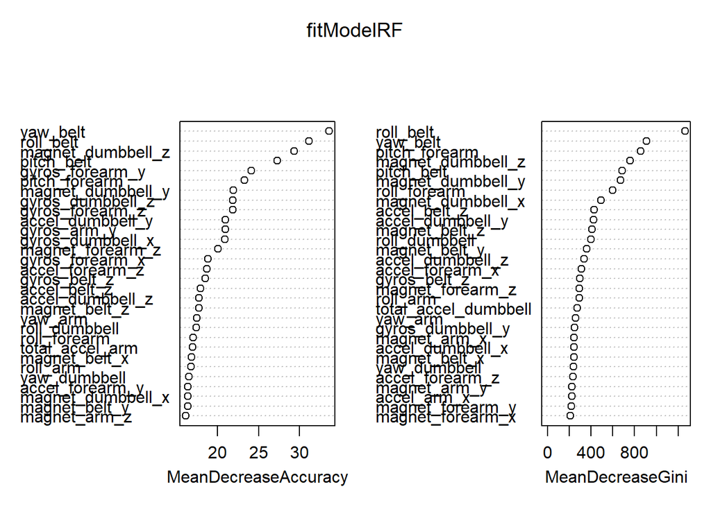

```r
varImpPlot(fitModelRF)
```

## Sources

Human Activity Recognition data set: http://groupware.les.inf.puc-rio.br/har